# Regression Models Project

Tihana Mirkovic

### **Executive Summary**

The *Motor Trend* magazine is interested in exploring the relationship between a number of variables and miles per gallon (MPG) (outcome), for different automobiles (1973-1974 models). The data is found in the source file `mtcars`, which was originally extracted from the 1974 edition of the *Motor Trend* US magazine. It is comprised of fuel consumption (MPG) and 10 aspects of automobile design and performance for 32 automobiles.

In particular, in this analysis, two questions are going to be addressed:

```
- "Is an automatic or manual transmission better for MPG"
- "Quantify the MPG difference between automatic and manual transmissions"
```

### **Exploratory Data Analysis**

The data set `mtcars` is loaded, as well as the libraries used in this analysis. Following the initial inspection of the variables, the class of a number of dichotomous parameters is converted from numeric to factor.

```r
library(dplyr)
library(ggplot2)
library(gridExtra)
data(mtcars)
```

```r
##str(mtcars) - output not shown for space reasons
```

```r
mtcars$am <- factor(mtcars$am, labels = c("Automatic", "Manual"))
mtcars$cyl <- factor(mtcars$cyl)
mtcars$vs <- factor(mtcars$vs)
mtcars$gear <- factor(mtcars$gear)
mtcars$carb <- factor(mtcars$carb)
```

#### **Inference: Analyzing MPG Means for Automatic and Manual Cars**

Insight into the two subpopulations (automatic vs manual) can be gaged from the plots in **Figures 1 and 2** of the Appendix. Then a t-test is performed to test if the two means are statistically different. We are assuming that MPG has a normal distribution, as illustrate in **Figure 1** of the Appendix. The null hypothesis, H0, is assuming that the two means are not different and that they stem from the same population.

The averages and the standard deviation of MPG values for the two subgroups of cars (automatic and manual) are compared, where the mean MPG value for manual cars is 7.24 MPGs larger.

```r
t.test(mtcars$mpg~mtcars$am, conf.level=0.95)
```

```
##
##  Welch Two Sample t-test
##
## data:  mtcars$mpg by mtcars$am
## t = -3.7671, df = 18.332, p-value = 0.001374
## alternative hypothesis: true difference in means is not equal to 0
## 95 percent confidence interval:
##  -11.280194  -3.209684
## sample estimates:
## mean in group Automatic    mean in group Manual
##                17.14737                24.39231
```

The mean MPG value for manual cars is 24.39231 MPG (7.24 MPGs larger than for automatic transmission cars). The t-test, with a p-value=0.001374, leads to the rejection of the null hypothesis, and suggestions that the two means are indeed different and that manual cars are outperforming automatic cars, given all other factors are identical. The 95% confidence interval suggests that the difference in the means of MPG values is between 3.21 and 11.28 MPGs.

#### **Regression Analysis**

In the previous section we have shown that the transmission type has an impact on the MPG value, but a further nine automobile parameters could also potentially have an influence on MPG values. The correlation between MPG and all other car parameters is investigated first, showing how some have a positive and some a negative correlation with MPG. A quick way to visualize some of the dependencies among the different variables is to examine the scattterplot matrix (**Figure 3**).

```r
##data(mtcars)
##sort(cor(mtcars)[1,]) - output not shown for space reasons
```

#### **Linear Regression**

```r
summary(lm(mpg~am, data=mtcars))$coef
```

```
##              Estimate Std. Error   t value     Pr(>|t|)
## (Intercept) 17.147368   1.124603 15.247492 1.133983e-15
## amManual     7.244939   1.764422  4.106127 2.850207e-04
```

From a linear regression model, where only transmission type is included, we don’t learn much more than in our previous analysis. The coefficients suggest that:

- intercept = the mean MPG value for automatic transmission is 17.147
- am coefficient = mean MPG value for manual transmission is: 17.147+7.245=24.392.

The p-value suggests that inclusion of the transmission type into the model is significant, but the low R-squared value means that this approach only explains about 36% of the variance. A better model is needed.

#### **Multivariable Regression Analysis**

##### **Model with all Parameters**

Inclusion of all the parameters, would be modeled with `summary(lm(mpg~., data=mtcars))`, but that would probably lead to overfitting. A better model, with more carefully selected parameters is needed.

##### **The Best Model**

To find the best model, we use the step() function, based on a stepwise algorithm approach, which picks the most dominant parameters needed to model MPG.

```r
bestmodel = step(lm(data = mtcars, mpg ~ .), trace=0)
summary(bestmodel)
```

```
##
## Call:
## lm(formula = mpg ~ cyl + hp + wt + am, data = mtcars)
##
## Residuals:
##     Min      1Q  Median      3Q     Max
## -3.9387 -1.2560 -0.4013  1.1253  5.0513
##
## Coefficients:
##             Estimate Std. Error t value Pr(>|t|)
## (Intercept) 33.70832    2.60489  12.940 7.73e-13 ***
## cyl6        -3.03134    1.40728  -2.154  0.04068 *
## cyl8        -2.16368    2.28425  -0.947  0.35225
## hp          -0.03211    0.01369  -2.345  0.02693 *
## wt          -2.49683    0.88559  -2.819  0.00908 **
## amManual     1.80921    1.39630   1.296  0.20646
## ---
## Signif. codes:  0 '***' 0.001 '**' 0.01 '*' 0.05 '.' 0.1 ' ' 1
##
## Residual standard error: 2.41 on 26 degrees of freedom
## Multiple R-squared:  0.8659, Adjusted R-squared:  0.8401
## F-statistic: 33.57 on 5 and 26 DF,  p-value: 1.506e-10
```

### **Residuals and Diagnostics**

```r
influence<-sort(round(dfbetas(bestmodel)[, 4],3))
tail(influence)
```

```
## Cadillac Fleetwood          Mazda RX4       Lotus Europa
##              0.101              0.136              0.210
##   Dodge Challenger        AMC Javelin      Maserati Bora
##              0.295              0.350              0.525
```

```r
leverage<-sort(round(hatvalues(bestmodel), 3))
tail(leverage)
```

```
##       Mazda RX4 Wag  Cadillac Fleetwood   Chrysler Imperial
##               0.250               0.250               0.261
##       Toyota Corona Lincoln Continental       Maserati Bora
##               0.278               0.294               0.471
```

### **Appendix: Figures**

##### **Figure 1**

The distribution of MPG is illustrated on a histogram. For comparison, a density plot and a normal curve have been overlaid on top of the histogram. On the right, separate histograms illustrate the distribution of MPG values among the two subgroups of cars differentiated by transmission type.

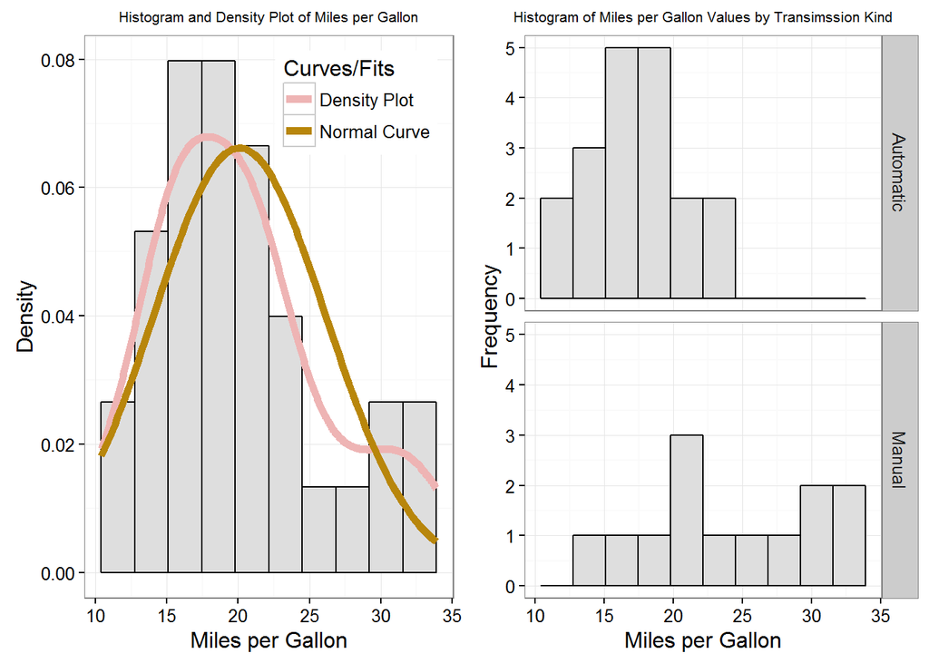

```r
mtcars$am <- factor(mtcars$am, labels = c("Automatic", "Manual"))
g1<-ggplot(mtcars, aes(x=mpg)) + geom_histogram(aes(y=..density..),
breaks = seq(min(mtcars$mpg), max(mtcars$mpg), (max(mtcars$mpg)-min(mtcars$mpg))/10),
fill=I("grey87"),col=I("black"))+
labs(title="Histogram and Density Plot of Miles per Gallon", x="Miles per Gallon", y="Density")+
stat_density(geom="line", col="RosyBrown2", lwd=2, aes(linetype="Density Plot"), show.legend=TRUE)+
stat_function(fun=dnorm, col="DarkGoldenrod",args=list(mean=mean(mtcars$mpg), sd=sd(mtcars$mpg)),
lwd=2, aes(linetype="Normal Curve"), show.legend = TRUE)+
scale_color_manual(values=c("Density Plot","Normal Distribution"))+
scale_linetype_manual(name="Curves/Fits", values=c(1,1))+
guides(linetype=guide_legend(override.aes=list(colour = c("RosyBrown2","DarkGoldenrod"))))+
theme_bw()+
theme(legend.justification=c(1,1), legend.position=c(1,1))+
        theme(plot.title = element_text(size = 8))
g3<-ggplot(mtcars, aes(x=mpg)) +
        geom_histogram(breaks = seq(min(mtcars$mpg), max(mtcars$mpg),
        (max(mtcars$mpg)-min(mtcars$mpg))/10),
        fill=I("grey87"),col=I("black"))+facet_grid(am~.)+
        labs(title="Histogram of Miles per Gallon Values by Transimssion Kind",
        x="Miles per Gallon", y="Frequency")+
        theme_bw()+
        theme(plot.title = element_text(size = 8))
grid.arrange(g1, g3, ncol=2)
```

##### **Figure 2**

A violin plot and a box plot illustrate the dependence of MPG on the transmission type, indicating higher MPG values for the cars with a manual transmission.

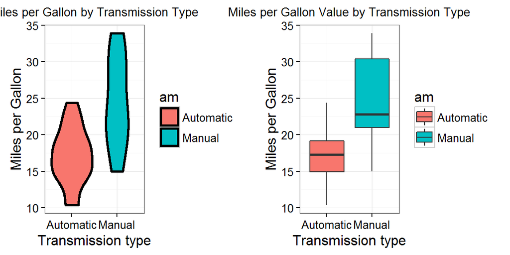

```r
mtcars$am <- factor(mtcars$am, labels = c("Automatic", "Manual"))
##Violin plot
g = ggplot(data = mtcars, aes(y = mpg, x = am, fill = am))
g = g + geom_violin(colour = "black", size = 1)
g = g + xlab("Transmission type") + ylab("Miles per Gallon")+theme_bw()
g= g+ggtitle("Miles per Gallon by Transmission Type")+
        theme(plot.title = element_text(size = 10))
g2=ggplot(data = mtcars,aes(y = mpg, x = am, fill = am))
g2=g2+geom_boxplot()
g2=g2+ggtitle("Miles per Gallon Value by Transmission Type")
g2=g2+xlab("Transmission type")+ ylab("Miles per Gallon")+theme_bw()+
        theme(plot.title = element_text(size = 10))
grid.arrange(g, g2, ncol=2)
```

##### **Figure 3**

Scatter Plot Matrix Illustrating Correlations Among mtcars Predictor Variables

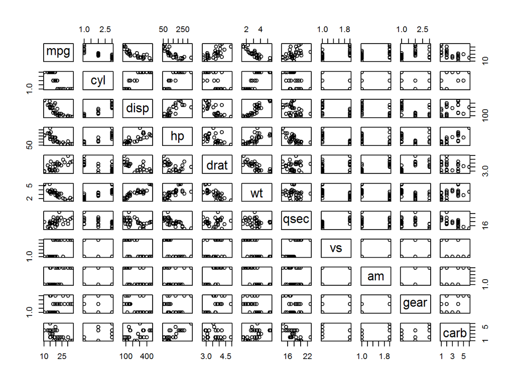

```r
pairs(mtcars)
```

##### **Figure 4**

Showing the dominance of weight as a factor and also illustrating how manual cars tend to be lighter, whereas automatic cars tend to be heavier. Lighter cars have much better MPG values.

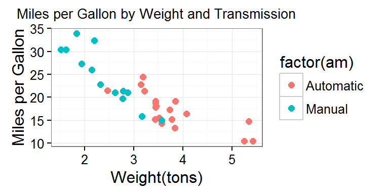

```r
mtcars$am <- factor(mtcars$am, labels = c("Automatic", "Manual"))
ggplot(mtcars, aes(x=wt, y=mpg))+geom_point(aes(colour=factor(am)), size=2)+
theme_bw()+ ggtitle("Miles per Gallon by Weight and Transmission")+ xlab("Weight(tons)")+
ylab("Miles per Gallon")+theme(plot.title = element_text(size = 10))
```

##### **Figure 5**

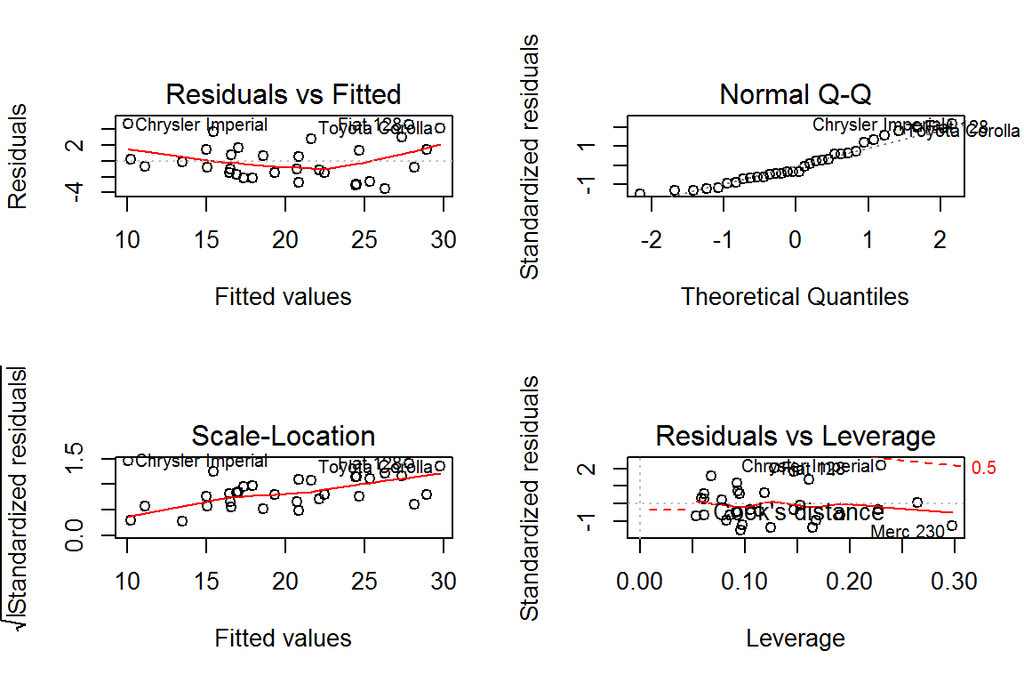

```r
data(mtcars);par(mfrow=c(2,2))
bestmodel<-lm(mpg ~ wt + qsec + am, data=mtcars)
plot(bestmodel)
```